# Wizard Wells: Formatting

## Collapse Redundant Readings

There are several cases where multiple well levels were recorded for 1 well during each “data season” - currently December 10 - February 28.

Collapse these into 1 value per well per year - using mean until told otherwise.

Note visual inspection of these instances mostly revealed these were measurements recorded on the same day or within a few days with depth values quite similar (off by some hundredths)

Also add a simpler well id column so it’s short enough to see when printed to console

```r
# add a simpler/shorter wellID
wellKeyUpdater <- data.frame(USGS_ID = unique(wells3_0$USGS_ID),
                             wellID = 1:length(unique(wells3_0$USGS_ID)))

# get mean depth level for each well, in each adjusted year
wells3_1 <- wells3_0 %>%
  left_join(wellKeyUpdater, by = "USGS_ID") %>%
 # group by wellID and YearAdjusted, add other columns simply to retain values
  group_by(USGS_ID, masterid, wellID, LAND_SURFACE_ALTITUDE, YearAdjusted) %>%
  summarize(Depth_ft = mean(DEPTH_TO_WATER),
            Date = mean(Date), DOY = mean(DOY), Year = mean(Year)) %>%
  arrange(wellID, YearAdjusted)

# add a lat and long column based on sf geometry column
coords <- st_coordinates(wells3_1)
wells3 <- cbind(wells3_1, coords)
```

## Convert Units

conversions:

- convert depth-to-water from feet to meters
- convert land surface altitude to meters (Sea Level Datum of 1929) - assumed to be in feet although Metadata doesn’t specify
- derive water table elevation

```r
# feet to meters
wells3$Depth_m <- wells3$Depth_ft * 0.3048
wells3$SurfaceAltitude_m <- wells3$LAND_SURFACE_ALTITUDE * 0.3048

# derive water table elevation
wells3$wtElev_m <- wells3$SurfaceAltitude_m - wells3$Depth_m
```

## Calculate Change in Water Level

Include a column for change in water level

Calculated as change since previous year, with negatives indicating a water level drop. Calculated by well. Also flags the number of years since last measurement, so “change in water level” values over more than 1 year could be omitted.

Also add a “better” (shorter) wellID

```r
# calculate the change in water table elevation since previous measurement, by well
wells4 <- wells3 %>%
  group_by(wellID) %>%
  arrange(wellID,YearAdjusted) %>%
  mutate(changeInWaterLevel = c(NA, diff(wtElev_m))) %>%
  # and add the number of years that "change" spanned
  mutate(changeInterval = c(NA, diff(YearAdjusted))) %>%
  mutate(DOY = as.integer(DOY),
         changeInterval = as.integer(changeInterval)) %>%
  rename(YearAdj = YearAdjusted,
         dWtElevm = changeInWaterLevel,
         Interval = changeInterval) %>%
  # and select/order columns to retain
  select(c(wellID, masterid, Date, DOY, Year, YearAdj, Depth_m,
           wtElev_m, dWtElevm, Interval, X, Y))
```

Note I removed the USGS_ID because it caused a “too long” error when writing out the shapefile and I didn’t feel like fixing it.

## Summarize Data

Some stats on the remaining data

```r
# how many unique wells?
length(unique(wells4$wellID))
```

```
## [1] 63
```

```r
# unique wells by region?
wells4 %>%
  group_by(masterid) %>%
  summarize(n = n_distinct(wellID))
```

```
## Simple feature collection with 3 features and 2 fields
## geometry type:  MULTIPOINT
## dimension:      XY
## bbox:           xmin: -101.0879 ymin: 39.23339 xmax: -100.3692 ymax: 39.56223
## epsg (SRID):    4269
## proj4string:    +proj=longlat +ellps=GRS80 +towgs84=0,0,0,0,0,0,0 +no_defs
## # A tibble: 3 x 3
##   masterid      n                                                 geometry
##   <chr>     <int>                                         <MULTIPOINT [°]>
## 1 buffer       45 (-101.0879 39.33988, -101.0801 39.41261, -101.0678 39.3…
## 2 null_geo9     9 (-100.9365 39.37962, -100.9325 39.46113, -100.9202 39.4…
## 3 sheridan      9 (-100.6952 39.37987, -100.6458 39.409, -100.6454 39.368…
```

```r
# how many single-year change data points?
sum(wells4$Interval ==1, na.rm=TRUE)
```

```
## [1] 994
```

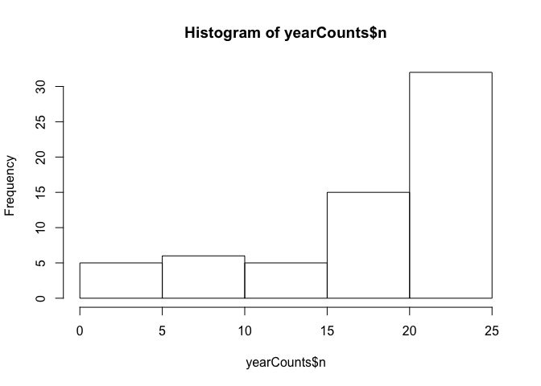

```r
# how many years by well?
yearCounts <- wells4 %>%
  group_by(wellID) %>%
  summarize(n = n_distinct(YearAdj))
hist(yearCounts$n)
```

```r
# how many wells each year?
wellNums <- wells4 %>%
  group_by(YearAdj) %>%
  summarize(n = n())
summary(wellNums$n)
```

```
##    Min. 1st Qu.  Median    Mean 3rd Qu.    Max.
##   26.00   48.25   52.00   49.77   53.00   56.00
```

# Export Cleaned Data

export for downstream analyses

```r
write_sf(wells4,
         paste0(wellDir,'/cleaned/wells_cleaned_clipped_1996-2017_jimRemoved.shp'))
write_sf(wells4,
         paste0(wellDir,'/cleaned/wells_cleaned_clipped_1996-2017_jimRemoved.csv'))
```